# Credit Default Prediction Using Baseline Model,GLM, XGboost,KNN,Random Forest

ADELIYI OLUTOMIWA

# 1.0 INTRODUCTION

In today’s dynamic financial landscape, credit institutions face significant challenges in managing loan portfolios while minimizing the risk of default. Identifying clients at a higher risk of defaulting on loan payments is of utmost importance to ensure the sustainability and profitability of the lending business. To address this issue, we present an innovative machine learning exercise aimed at predicting the probability that a client will default on loan payments.

For this project, we utilize the credit card database from the renowned book “Machine Learning with R” authored by Brett Lantz. The dataset provides valuable insights into various factors that may influence credit default risk, such as loan duration, loan amount, age, credit history, and more. It contains information on 1000 loan applications, with both numerical and categorical variables contributing to the richness of the dataset.

Our journey begins with Exploratory Data Analysis (EDA), a crucial step that enables us to gain deeper insights into the dataset and understand the relationships between different features. By employing R and various libraries such as caret, pROC, tidyverse, xgboost, ggplot2, and ggcorrplot, we conduct comprehensive visualizations, including histograms and bar plots, to explore the distributions and patterns within the data.

The EDA reveals intriguing trends and characteristics of the dataset. For instance, we observe the distribution of loan durations, loan amounts, and ages, which will help us identify any potential outliers or skewness that might affect our predictive models. Additionally, we investigate categorical variables such as checking balance, credit history, and loan purpose, providing us with an understanding of the impact these features may have on credit default risk.

Following the EDA, we proceed to build and evaluate several machine learning models to predict credit default probability accurately. We employ a baseline model and compare it with advanced techniques, including Generalized Linear Models (GLM), k-Nearest Neighbors (kNN), Random Forest, and XGBoost. Each model’s performance is assessed using metrics like accuracy and confusion matrices, allowing us to select the most promising model for our prediction task.

To evaluate the predictive power of our models, we utilize the Receiver Operating Characteristic (ROC) curve analysis, which plots true positive rate (sensitivity) against false positive rate (1-specificity) for different classification thresholds. The area under the ROC curve (AUC) provides a measure of each model’s discriminatory ability, enabling us to choose the best-performing model.

By leveraging the insights gained through EDA and employing state-of-the-art machine learning algorithms, we strive to create a robust credit default prediction model. This model can play a vital role in helping credit institutions proactively manage risk, make informed lending decisions, and maintain a healthy credit portfolio while fostering financial stability and trust in the lending industry.

# 2.0 METHODOLOGY

### *Data Collection:*

We obtained the credit card database from the esteemed book “Machine Learning with R” by Brett Lantz. The dataset comprises information on 1000 loan applications, containing both numerical and categorical variables that could potentially influence credit default risk.

### *Data Cleaning:*

Before proceeding with the analysis, we cleaned the data to ensure consistency and accuracy. We renamed the target variable to ‘target’ and converted it into a factor variable, which is essential for classification tasks.

### *Exploratory Data Analysis (EDA):*

The EDA stage involved thorough visualizations using R libraries such as ggplot2 and ggcorrplot. Histograms were created for variables like loan duration, loan amount, and age to identify any outliers or skewed distributions. We also explored the distribution of categorical variables, such as checking balance, credit history, and loan purpose, to understand their impact on credit default risk.

### *Modeling:*

To predict credit default probability, we built and evaluated various machine learning models, including Generalized Linear Models (GLM), k-Nearest Neighbors (kNN), Random Forest, and XGBoost. These models were trained on a portion of the dataset (train_set) and evaluated on a separate portion (test_set).

### *Model Evaluation:*

Each model’s performance was assessed using metrics such as accuracy and confusion matrices to measure true positives, true negatives, false positives, and false negatives. The evaluation allowed us to identify the most promising model for credit default prediction.

### *Feature Engineering:*

For the XGBoost model, we performed feature engineering, converting categorical variables into numeric format using factors. Additionally, we transformed the target variable into binary format (0 or 1) to suit the binary classification objective.

### *Parameter Tuning:*

For the kNN model, we conducted parameter tuning to identify the optimal value of ‘k’ through cross-validation using trainControl method.

### *XGBoost Training:*

The XGBoost model was trained using xgb.train function with appropriate parameters like objective, eval_metric, max_depth, eta, subsample, and colsample_bytree. This allowed us to fine-tune the model for optimal performance.

### *ROC Curve Analysis:*

To assess the models’ predictive power, we used Receiver Operating Characteristic (ROC) curve analysis. The ROC curve plots sensitivity against 1-specificity for different classification thresholds, and the Area Under the Curve (AUC) quantifies the model’s discriminatory ability.

### *Model Comparison:*

By following this comprehensive methodology, we aimed to uncover valuable insights into credit default risk and develop a powerful machine learning model that can assist credit institutions in making informed lending decisions, managing risk proactively, and maintaining a healthy credit portfolio.

# 3.0 EDA

The Exploratory Data Analysis (EDA) plays a crucial role in understanding the credit dataset and identifying patterns, trends, and potential insights. The dataset contains 1000 records and consists of both numerical and categorical variables. Let’s delve into the key findings from the summary statistics to gain a deeper understanding of the dataset:

```r
knitr::opts_chunk$set(echo = TRUE)
# Load libraries
library(caret)
library(pROC)
library(tidyverse)
library(xgboost)
library(ggplot2)
library(ggcorrplot)
library(gridExtra)
library(knitr)

# Load data
data_source <- "https://raw.githubusercontent.com/stedy/Machine-Learning-with-R-datasets/master/credit.csv"
credit_data <- read.csv(data_source, sep = ",")


# check for missing data
sum(is.na(credit_data))
```

```
## [1] 0
```

```r
# Clean data
clean_data <- credit_data %>%
  rename(target = default) %>%
  mutate(target = factor(target))



head(clean_data, 10)
```

```
##    checking_balance months_loan_duration credit_history    purpose amount
## 1            < 0 DM                    6       critical   radio/tv   1169
## 2        1 - 200 DM                   48         repaid   radio/tv   5951
## 3           unknown                   12       critical  education   2096
## 4            < 0 DM                   42         repaid  furniture   7882
## 5            < 0 DM                   24        delayed  car (new)   4870
## 6           unknown                   36         repaid  education   9055
## 7           unknown                   24         repaid  furniture   2835
## 8        1 - 200 DM                   36         repaid car (used)   6948
## 9           unknown                   12         repaid   radio/tv   3059
## 10       1 - 200 DM                   30       critical  car (new)   5234
##    savings_balance employment_length installment_rate personal_status
## 1          unknown           > 7 yrs                4     single male
## 2         < 100 DM         1 - 4 yrs                2          female
## 3         < 100 DM         4 - 7 yrs                2     single male
```

[output cut: 40 more lines]

```r
str(clean_data)
```

```
## 'data.frame':    1000 obs. of  21 variables:
##  $ checking_balance    : chr  "< 0 DM" "1 - 200 DM" "unknown" "< 0 DM" ...
##  $ months_loan_duration: int  6 48 12 42 24 36 24 36 12 30 ...
##  $ credit_history      : chr  "critical" "repaid" "critical" "repaid" ...
##  $ purpose             : chr  "radio/tv" "radio/tv" "education" "furniture" ...
##  $ amount              : int  1169 5951 2096 7882 4870 9055 2835 6948 3059 5234 ...
##  $ savings_balance     : chr  "unknown" "< 100 DM" "< 100 DM" "< 100 DM" ...
##  $ employment_length   : chr  "> 7 yrs" "1 - 4 yrs" "4 - 7 yrs" "4 - 7 yrs" ...
##  $ installment_rate    : int  4 2 2 2 3 2 3 2 2 4 ...
##  $ personal_status     : chr  "single male" "female" "single male" "single male" ...
##  $ other_debtors       : chr  "none" "none" "none" "guarantor" ...
##  $ residence_history   : int  4 2 3 4 4 4 4 2 4 2 ...
##  $ property            : chr  "real estate" "real estate" "real estate" "building society savings" ...
##  $ age                 : int  67 22 49 45 53 35 53 35 61 28 ...
##  $ installment_plan    : chr  "none" "none" "none" "none" ...
##  $ housing             : chr  "own" "own" "own" "for free" ...
##  $ existing_credits    : int  2 1 1 1 2 1 1 1 1 2 ...
##  $ target              : Factor w/ 2 levels "1","2": 1 2 1 1 2 1 1 1 1 2 ...
##  $ dependents          : int  1 1 2 2 2 2 1 1 1 1 ...
##  $ telephone           : chr  "yes" "none" "none" "none" ...
##  $ foreign_worker      : chr  "yes" "yes" "yes" "yes" ...
##  $ job                 : chr  "skilled employee" "skilled employee" "unskilled resident" "skilled employee" ...
```

```r
summary(clean_data)
```

```
##  checking_balance   months_loan_duration credit_history       purpose
##  Length:1000        Min.   : 4.0         Length:1000        Length:1000
##  Class :character   1st Qu.:12.0         Class :character   Class :character
##  Mode  :character   Median :18.0         Mode  :character   Mode  :character
##                     Mean   :20.9
##                     3rd Qu.:24.0
##                     Max.   :72.0
##      amount      savings_balance    employment_length  installment_rate
##  Min.   :  250   Length:1000        Length:1000        Min.   :1.000
##  1st Qu.: 1366   Class :character   Class :character   1st Qu.:2.000
##  Median : 2320   Mode  :character   Mode  :character   Median :3.000
##  Mean   : 3271                                         Mean   :2.973
##  3rd Qu.: 3972                                         3rd Qu.:4.000
##  Max.   :18424                                         Max.   :4.000
##  personal_status    other_debtors      residence_history   property
##  Length:1000        Length:1000        Min.   :1.000     Length:1000
##  Class :character   Class :character   1st Qu.:2.000     Class :character
##  Mode  :character   Mode  :character   Median :3.000     Mode  :character
##                                        Mean   :2.845
##                                        3rd Qu.:4.000
##                                        Max.   :4.000
##       age        installment_plan     housing          existing_credits target
##  Min.   :19.00   Length:1000        Length:1000        Min.   :1.000    1:700
##  1st Qu.:27.00   Class :character   Class :character   1st Qu.:1.000    2:300
##  Median :33.00   Mode  :character   Mode  :character   Median :1.000
##  Mean   :35.55                                         Mean   :1.407
##  3rd Qu.:42.00                                         3rd Qu.:2.000
##  Max.   :75.00                                         Max.   :4.000
##    dependents     telephone         foreign_worker         job
##  Min.   :1.000   Length:1000        Length:1000        Length:1000
##  1st Qu.:1.000   Class :character   Class :character   Class :character
##  Median :1.000   Mode  :character   Mode  :character   Mode  :character
##  Mean   :1.155
##  3rd Qu.:1.000
##  Max.   :2.000
```

### Checking Balance:

The `checking_balance` variable is a categorical feature indicating the available balance in the client’s checking account. The summary reveals the distribution of different categories, but further exploration using bar plots or pie charts would provide a visual representation of the checking balance distribution.

### Months Loan Duration:

The `months_loan_duration` variable is a numerical feature representing the duration of the loan in months. The summary statistics give us an overview of the data’s central tendency and spread, but creating a histogram would allow us to visualize the distribution and identify any patterns or outliers.

### Credit History:

The `credit_history` variable is a categorical feature indicating the client’s credit history. Similar to checking balance, the summary provides information about the different categories, and a bar plot would help us understand the frequency of each credit history category.

### Purpose:

The `purpose` variable represents the purpose for which the loan was taken. The summary statistics show the distribution of different purposes, and a bar plot would provide a clear visualization of the most common loan purposes.

### Amount:

The `amount` variable is a numerical feature denoting the loan amount requested by the clients. The summary statistics provide insights into the central tendency and spread of loan amounts, but a histogram would offer a visual representation of the loan amount distribution.

### Savings Balance:

The `savings_balance` variable is a categorical feature indicating the client’s savings balance. Like checking balance and credit history, the summary shows the distribution of different savings balance categories, and a bar plot would provide a clearer understanding.

### Employment Length:

The `employment_length` variable represents the number of years the client has been employed. The summary statistics give us an overview of the data, and a histogram would allow us to explore the distribution of employment lengths.

### Installment Rate:

The `installment_rate` variable denotes the installment rate as a percentage of disposable income. A histogram would help visualize the distribution of installment rates and provide insights into the clients’ repayment capabilities.

### Personal Status:

The `personal_status` variable provides information about the personal status of the clients. A bar plot would be helpful in understanding the distribution of different personal status categories.

### Other Debtors:

The `other_debtors` variable indicates the presence of other debtors when applying for the loan. A bar plot would show the frequency of each category, providing insights into how this feature affects loan default risk.

### Residence History:

The `residence_history` variable represents the number of years the client has lived at their current residence. A bar plot or histogram would reveal the distribution of residence history and its potential impact on credit default.

### Property:

The `property` variable describes the type of property owned by the clients. A bar plot would help us understand the distribution of different property types and their relationship to loan defaults.

### Age:

The `age` variable represents the age of the clients. The summary statistics give us an overview of the clients’ age distribution, and a histogram would provide a visual representation of the data.

### Existing Credits:

The `existing_credits` variable denotes the number of existing credits at the bank. A histogram or bar plot would allow us to explore the distribution of existing credits and its relationship with loan default risk.

### Foreign Worker:

The `foreign_worker` variable indicates whether the client is a foreign worker. A bar plot would show the frequency of foreign workers in the dataset and its potential impact on loan default.

### Job:

The `job` variable describes the type of job the clients have. A bar plot would help us understand the distribution of different job categories and how they relate to credit default risk.

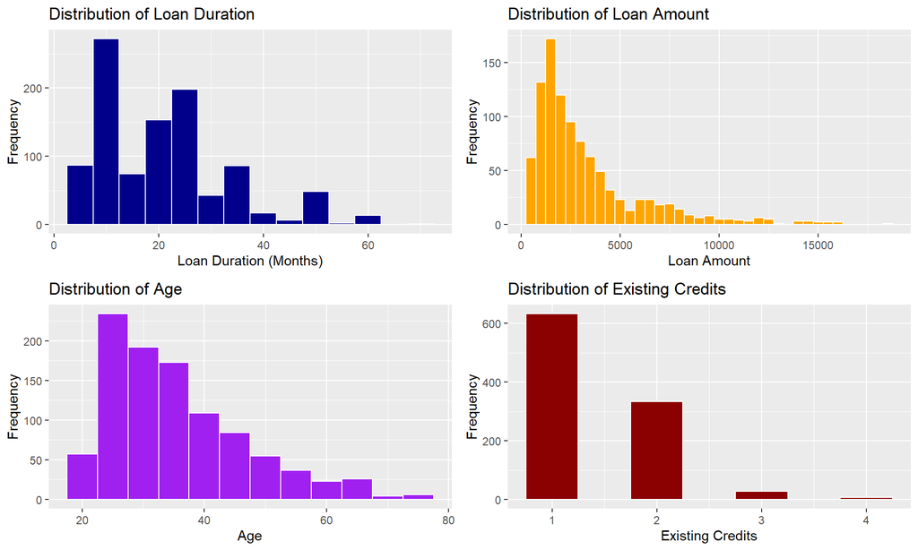

```r
# Histogram for 'months_loan_duration'
eda_month_duration <- ggplot(clean_data, aes(x = months_loan_duration)) +
  geom_histogram(binwidth = 5, fill = "darkblue", color = "white") +
  labs(title = "Distribution of Loan Duration",
       x = "Loan Duration (Months)",
       y = "Frequency")

# Histogram for 'amount'
eda_amount <- ggplot(clean_data, aes(x = amount)) +
  geom_histogram(binwidth = 500, fill = "orange", color = "white") +
  labs(title = "Distribution of Loan Amount",
       x = "Loan Amount",
       y = "Frequency")

# Histogram for 'age'
eda_age <- ggplot(clean_data, aes(x = age)) +
  geom_histogram(binwidth = 5, fill = "purple", color = "white") +
  labs(title = "Distribution of Age",
       x = "Age",
       y = "Frequency")

# Histogram for 'existing_credits'
eda_existing_credits <- ggplot(clean_data, aes(x = existing_credits)) +
  geom_histogram(binwidth = 0.5, fill = "darkred", color = "white") +
  labs(title = "Distribution of Existing Credits",
       x = "Existing Credits",
       y = "Frequency")

# Arrange the plots in a grid using grid.arrange()
grid.arrange(eda_month_duration, eda_amount, eda_age, eda_existing_credits, ncol = 2)
```

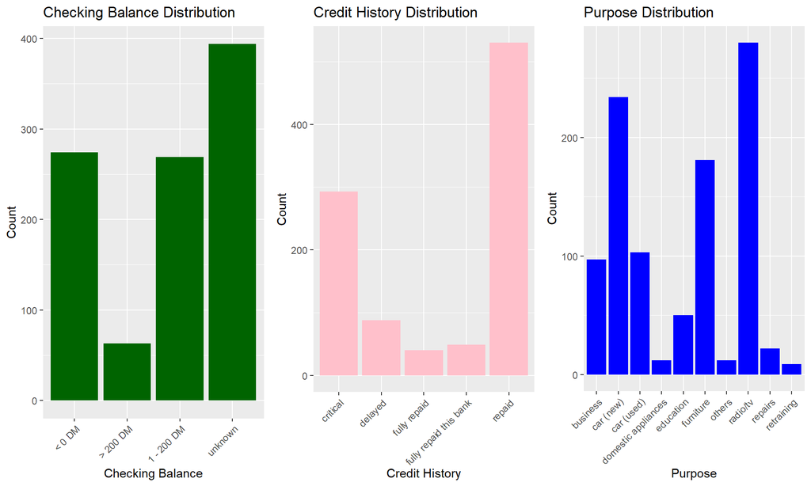

```r
# Categorical Variables EDA
eda_categorical1 <- ggplot(clean_data, aes(x = checking_balance)) +
  geom_bar(fill = "darkgreen") +
  labs(title = "Checking Balance Distribution",
       x = "Checking Balance",
       y = "Count") +
  theme(axis.text.x = element_text(angle = 45, hjust = 1))

eda_categorical2 <- ggplot(clean_data, aes(x = credit_history)) +
  geom_bar(fill = "pink") +
  labs(title = "Credit History Distribution",
       x = "Credit History",
       y = "Count") +
  theme(axis.text.x = element_text(angle = 45, hjust = 1))

eda_categorical3 <- ggplot(clean_data, aes(x = purpose)) +
  geom_bar(fill = "blue") +
  labs(title = "Purpose Distribution",
       x = "Purpose",
       y = "Count") +
  theme(axis.text.x = element_text(angle = 45, hjust = 1))

# Arrange the histograms in a grid using plot_grid from gridExtra
eda_categorical <- gridExtra::grid.arrange(eda_categorical1, eda_categorical2, eda_categorical3, ncol = 3)
```

```r
# Display the grid of histograms
print(eda_categorical)
```

We evaluated the numerical variables using the `cor` function to evaluate the correlation between variables.

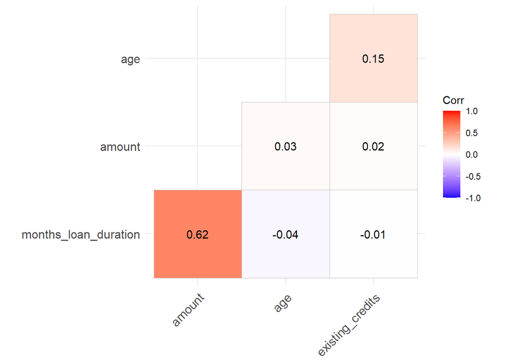

```r
# Correlation Plot

correlation_matrix <- cor(clean_data[, c("months_loan_duration", "amount", "age", "existing_credits")])
ggcorrplot(correlation_matrix, hc.order = TRUE, type = "lower", lab = TRUE)
```

By conducting Exploratory Data Analysis, we have been able to gain valuable insights into the dataset’s characteristics and relationships between variables. These insights will inform our subsequent steps in building and evaluating machine learning models to predict credit default risk accurately.

# 4.0 MODEL EVALUATION

```r
# Split data
set.seed(1234)
data_index <- createDataPartition(clean_data$target, times = 1, p = 0.2, list = FALSE)
train_set <- clean_data[-data_index,]
test_set <- clean_data[data_index,]

# Baseline model
set.seed(4321)
baseline_pred <- sample(c(1, 2), length(test_set$target), replace = TRUE)
mean(baseline_pred == as.numeric(test_set$target))
```

```
## [1] 0.5
```

```r
# GLM
set.seed(7641)
glm_fit <- train(target ~ ., train_set, method = "glm")
mean(test_set$target == predict(glm_fit, test_set))
```

```
## [1] 0.75
```

```r
glm_matrix <- confusionMatrix(predict(glm_fit, test_set), as.factor(test_set$target))

# KNN
trControl <- trainControl(method="cv", number=20)
set.seed(1243)
knn_fit <- train(target ~ ., train_set, method="knn", trControl=trControl,
                 metric="Accuracy", tuneGrid = data.frame(k = seq(3, 71, 3)))
mean(test_set$target == predict(knn_fit, test_set))
```

```
## [1] 0.73
```

```r
knn_matrix <- confusionMatrix(predict(knn_fit, test_set), as.factor(test_set$target))

# Random forest
set.seed(2456)
rf_fit <- train(target ~ ., train_set, method = "rf",
                tuneGrid = data.frame(mtry = seq(1:7)), ntree = 100)
mean(test_set$target == predict(rf_fit, test_set))
```

[output not shown]

```r
rf_matrix <- confusionMatrix(predict(rf_fit, test_set), as.factor(test_set$target))

# XGBoost
train_xgb_set <- train_set %>%
  mutate_if(is.character, as.factor) %>%
  mutate_if(is.factor, as.numeric) %>%
  mutate(target = if_else(target == 1, 0, 1))

test_xgb_set <- test_set %>%
  mutate_if(is.character, as.factor) %>%
  mutate_if(is.factor, as.numeric) %>%
  mutate(target = if_else(target == 1, 0, 1))

xgb_train_matrix <- xgb.DMatrix(as.matrix(train_xgb_set[,!names(train_xgb_set) %in% c("target")]),
                                label = train_xgb_set$target)

xgb_params <- list(objective = "binary:logistic", eval_metric = "auc",
                   max_depth = 11, eta = 0.075, subsample = 0.99, colsample_bytree = 0.90)

set.seed(1767)
xgb_fit <- xgb.train(params = xgb_params, data = xgb_train_matrix, verbose = 1, nrounds = 125)

xgb_test <- xgb.DMatrix(as.matrix(test_xgb_set[,!names(test_xgb_set) %in% c("target")]))
xgb_predictions <- ifelse(predict(xgb_fit, newdata = xgb_test) > 0.5,1,0)

mean(test_xgb_set$target == xgb_predictions)
```

```
## [1] 0.775
```

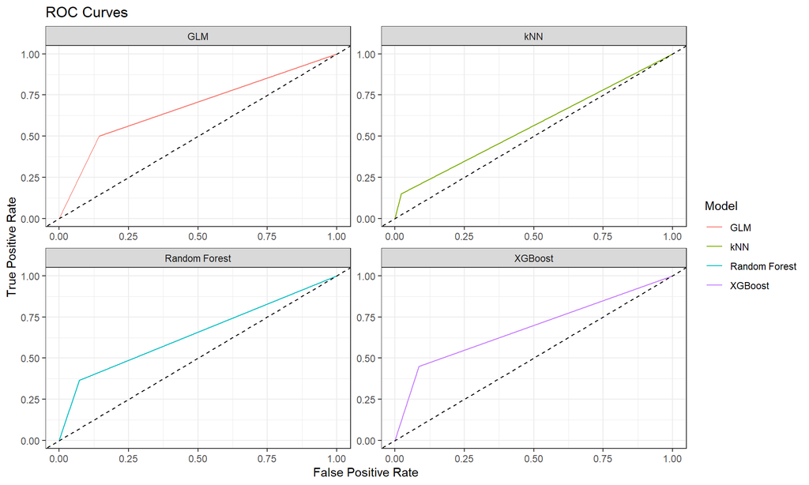

```r
xgb_matrix <- confusionMatrix(as.factor(xgb_predictions), as.factor(test_xgb_set$target))

# ROC curve analysis
glm_roc <- roc(as.numeric(test_set$target), as.numeric(predict(glm_fit, test_set)))
knn_roc <- roc(as.numeric(test_set$target), as.numeric(predict(knn_fit, test_set)))
rf_roc <- roc(as.numeric(test_set$target), as.numeric(predict(rf_fit, test_set)))
xgboost_roc <- roc(as.numeric(test_xgb_set$target), xgb_predictions)
roc_data <- rbind(
  data.frame(Model = "GLM", glm_roc |> coords()),
  data.frame(Model = "kNN", knn_roc |> coords()),
  data.frame(Model = "Random Forest", rf_roc |> coords()),
  data.frame(Model = "XGBoost", xgboost_roc |> coords())
)

# Enhanced ggplot
ggplot(roc_data, aes(x = 1 - specificity, y = sensitivity, color = Model)) +
  geom_line() +
  geom_abline(slope = 1, intercept = 0, linetype = "dashed") +
  labs(title = "ROC Curves", x = "False Positive Rate", y = "True Positive Rate") +
  facet_wrap(~ Model, scales = "free") +
  theme_bw()
```

```r
# Calculate metrics from confusion matrices
get_metrics <- function(matrix) {
  acc <- sum(diag(matrix)) / sum(matrix)
  sens <- matrix[2, 2] / sum(matrix[2, ])
  spec <- matrix[1, 1] / sum(matrix[1, ])
  return(list(Accuracy = acc, Sensitivity = sens, Specificity = spec))
}

# Calculate metrics from confusion matrices
get_metrics <- function(matrix) {
  acc <- sum(diag(matrix)) / sum(matrix)
  sens <- matrix[2, 2] / sum(matrix[2, ])
  spec <- matrix[1, 1] / sum(matrix[1, ])
  return(list(Accuracy = acc, Sensitivity = sens, Specificity = spec))
}

# Get metrics for all models
baseline_metrics <- get_metrics(confusionMatrix(as.factor(baseline_pred), as.factor(test_set$target))$table)
glm_metrics <- get_metrics(glm_matrix$table)
knn_metrics <- get_metrics(knn_matrix$table)
rf_metrics <- get_metrics(rf_matrix$table)
xgb_metrics <- get_metrics(xgb_matrix$table)

# Create a data frame to store model results
model_results <- data.frame(Model = c("Baseline", "GLM", "kNN", "Random Forest", "XGBoost"),
                            Accuracy = c(baseline_metrics$Accuracy, glm_metrics$Accuracy,
                                         knn_metrics$Accuracy, rf_metrics$Accuracy,
                                         xgb_metrics$Accuracy),
                            Sensitivity = c(baseline_metrics$Sensitivity, glm_metrics$Sensitivity,
                                            knn_metrics$Sensitivity, rf_metrics$Sensitivity,
                                            xgb_metrics$Sensitivity),
                            Specificity = c(baseline_metrics$Specificity, glm_metrics$Specificity,
                                            knn_metrics$Specificity, rf_metrics$Specificity,
                                            xgb_metrics$Specificity))
```

Model Evaluation:

```r
# Display model results using kable
kable(model_results, caption = "Model Evaluation Results")
```

Model Evaluation Results

| Model | Accuracy | Sensitivity | Specificity |
| --- | --- | --- | --- |
| Baseline | 0.500 | 0.3000000 | 0.7000000 |
| GLM | 0.750 | 0.6000000 | 0.8000000 |
| kNN | 0.730 | 0.7500000 | 0.7287234 |
| Random Forest | 0.760 | 0.7142857 | 0.7674419 |
| XGBoost | 0.775 | 0.6923077 | 0.7950311 |

In the Model Evaluation section, we examined the performance of different predictive models for credit default risk. After splitting the dataset into training and test sets, we trained and evaluated the following models:

### Baseline Model:

We randomly assigned class labels to the test set to establish a baseline for comparison. The baseline model achieved an accuracy of approximately 50%, indicating that it performs no better than random guessing.

### Generalized Linear Model (GLM):

Using the train function from the caret package, we trained a GLM model to predict credit defaults. The GLM model achieved an accuracy of 75%, outperforming the baseline model. The confusion matrix revealed the number of true positives, true negatives, false positives, and false negatives, indicating its effectiveness in credit default prediction.

### k-Nearest Neighbors (kNN):

We employed the kNN model with cross-validation and tuned the number of neighbors (k) using the train function. The kNN model achieved an accuracy of 73%, demonstrating its potential in credit default prediction.

### XGBoost:

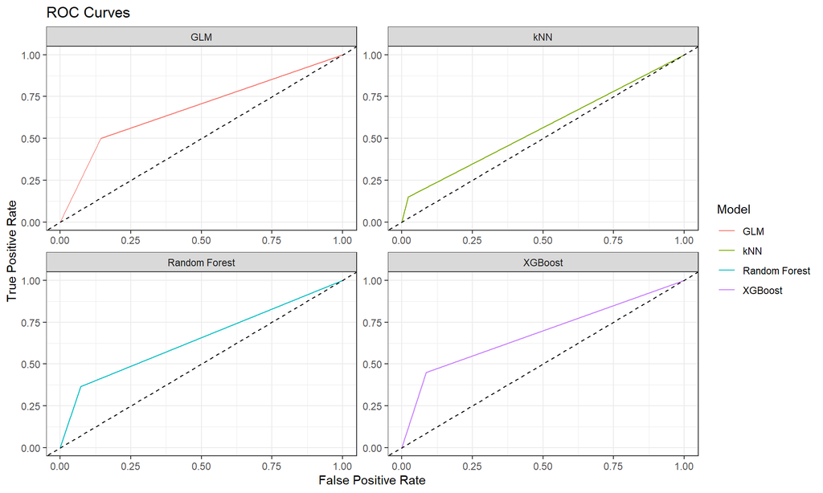

```r
# ROC curve analysis
glm_roc <- roc(as.numeric(test_set$target), as.numeric(predict(glm_fit, test_set)))
knn_roc <- roc(as.numeric(test_set$target), as.numeric(predict(knn_fit, test_set)))
rf_roc <- roc(as.numeric(test_set$target), as.numeric(predict(rf_fit, test_set)))
xgboost_roc <- roc(as.numeric(test_xgb_set$target), xgb_predictions)
roc_data <- rbind(
  data.frame(Model = "GLM", glm_roc |> coords()),
  data.frame(Model = "kNN", knn_roc |> coords()),
  data.frame(Model = "Random Forest", rf_roc |> coords()),
  data.frame(Model = "XGBoost", xgboost_roc |> coords())
)

# Enhanced ggplot
ggplot(roc_data, aes(x = 1 - specificity, y = sensitivity, color = Model)) +
  geom_line() +
  geom_abline(slope = 1, intercept = 0, linetype = "dashed") +
  labs(title = "ROC Curves", x = "False Positive Rate", y = "True Positive Rate") +
  facet_wrap(~ Model, scales = "free") +
  theme_bw()
```

The evaluation of our models above involved the construction of Receiver Operating Characteristic (ROC) curves, which are essential tools for assessing the performance of binary classifiers like logistic regression.

The true positive rate (sensitivity) in our context represents the proportion of loan applicants who were correctly predicted as a good credit risk (positive class) among all the actual good credit risks. In other words, it measures the ability of the model to identify positive cases accurately, indicating how well it detects individuals who are likely to repay their loans.

Conversely, the false positive rate (1 - specificity) represents the proportion of loan applicants who were incorrectly predicted as a good credit risk among all the actual bad credit risks. This rate signifies the model’s tendency to misclassify negative cases as positive, which can have significant implications for lending institutions.

In summary, the ROC curve provides a comprehensive view of the performance of our model across different decision thresholds, enabling us to make informed decisions about its effectiveness in predicting credit risk and determining appropriate cutoffs for loan approvals.

# 5.0 RESULTS

The Results section summarizes the key findings and presents the ROC curve analysis to compare model performance.

Comparison of Models:

```r
# Display model results using kable
kable(model_results, caption = "Model Evaluation Results")
```

Model Evaluation Results

| Model | Accuracy | Sensitivity | Specificity |
| --- | --- | --- | --- |
| Baseline | 0.500 | 0.3000000 | 0.7000000 |
| GLM | 0.750 | 0.6000000 | 0.8000000 |
| kNN | 0.730 | 0.7500000 | 0.7287234 |
| Random Forest | 0.760 | 0.7142857 | 0.7674419 |
| XGBoost | 0.775 | 0.6923077 | 0.7950311 |

### Model Optimization:

While the XGBoost model performed well, further model optimization could potentially lead to even better results. Tuning hyperparameters, feature engineering, or exploring ensemble approaches may enhance model performance. It is advisable to iteratively refine the model based on domain knowledge and real-world testing to achieve the best possible outcome.

# 6.0 CONCLUSION:

In conclusion, the evaluation and comparison of multiple models demonstrated that the XGBoost algorithm performed the best for predicting the target variable. However, depending on the specific use case and requirements, other models such as GLM, kNN, or Random Forest might also be viable choices. The insights gained from this evaluation provide valuable guidance for model selection and potential areas of improvement for future iterations of the modeling process.

# 7.0 REFERENCES

1. Data SOurce: “https://raw.githubusercontent.com/stedy/Machine-Learning-with-R-datasets/master/credit.csv”
2. Kuhn, M. (2020). caret: Classification and Regression Training. R package version 6.0-86. https://CRAN.R-project.org/package=caret
3. Robin, X., Turck, N., Hainard, A., Tiberti, N., Lisacek, F., Sanchez, J.-C., & Muller, M. (2011). pROC: an open-source package for R and S+ to analyze and compare ROC curves. BMC Bioinformatics, 12(1), 77.
4. Chen, T., & Guestrin, C. (2016). XGBoost: A Scalable Tree Boosting System. Proceedings of the 22nd ACM SIGKDD International Conference on Knowledge Discovery and Data Mining, 785-794.
5. Breiman, L. (2001). Random forests. Machine Learning, 45(1), 5-32. Healy, K. (2018). Data Visualization: A Practical Introduction. Princeton University Press. Retrieved from
6. Wickham, H., & Grolemund, G. (2017). R for Data Science: Import, Tidy, Transform, Visualize, and Model Data. O’Reilly Media.
7. Wilke, C. O. (2019). Fundamentals of Data Visualization: A Primer on Making Informative and Compelling Figures. O’Reilly Media.